# Who got the flushot?

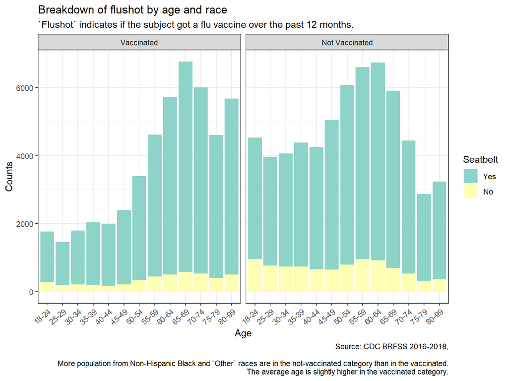

```r
ggplot(na.omit(cdc), aes(x = agefact, fill = sbfact)) +
geom_bar() +
theme_bw() +
guides(fill=guide_legend(title="Seatbelt")) +
scale_fill_brewer(palette = "Set3") +
facet_grid(~flufact) +
theme(axis.text.x = element_text(angle=40, hjust=1)) +
labs(x="Age",
     y="Counts",
     title="Breakdown of flushot by age and race",
     subtitle="`Flushot` indicates if the subject got a flu vaccine over the past 12 months.",
     caption="Source: CDC BRFSS 2016-2018,

     More population from Non-Hispanic Black and `Other` races are in the not-vaccinated category than in the vaccinated.
     The average age is slightly higher in the vaccinated category.")
```

- Now, this plot shows the effects of `age` and `seatbelt` on `flushot`.
- The odds of `not always wearing seatbelt` appears substantially higher in the `not vaccinated` category than in the `vaccinated`.
- Build a simpler graph once again.

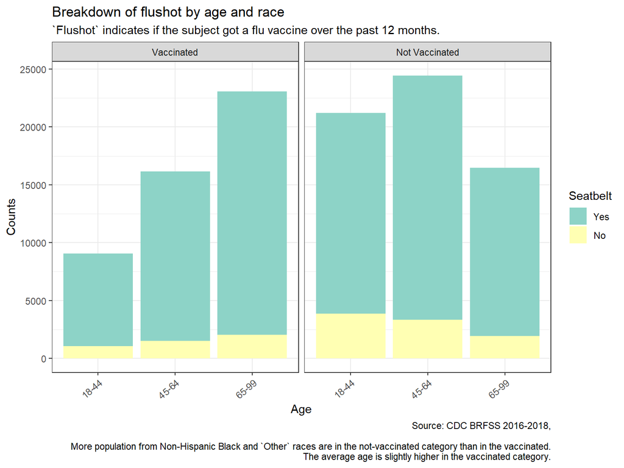

```r
ggplot(na.omit(cdc), aes(x = age3, fill = sbfact)) +
geom_bar() +
theme_bw() +
guides(fill=guide_legend(title="Seatbelt")) +
scale_fill_brewer(palette = "Set3") +
facet_grid(~flufact) +
theme(axis.text.x = element_text(angle=40, hjust=1)) +
labs(x="Age",
     y="Counts",
     title="Breakdown of flushot by age and race",
     subtitle="`Flushot` indicates if the subject got a flu vaccine over the past 12 months.",
     caption="Source: CDC BRFSS 2016-2018,

     More population from Non-Hispanic Black and `Other` races are in the not-vaccinated category than in the vaccinated.
     The average age is slightly higher in the vaccinated category.")
```

- It shows the more odds of `not always wearing seatbelt` group on the `not vaccinated` side clearer here.

# 7 Discussion

My analyses were on a model with a binary outcome, `flushot`, whether or not the subject has got flu vaccination over the past 12 months. It is an extremely important public health question since if an increasing number of people refuse to get yearly vaccinated for seasonal flu, then the herd immunity does not hold any more, and the danger of flu will increase. Hence, knowing who tend not to have received flu vaccination is important. Using basic personal information such as age, race, sex, and education level from the survey data set from BRFSS, I could build a logistic regression model that might help answer my two questions as introduced at the beginning:

1. Who has received flu vaccination over the past 12 months? Can we predict who has received it based on the information such as age, race, sex, and education level?
2. Considering other information mentioned above, whether the subject “always” wears seat belts while driving has a significant impact on whether the subject has received flu vaccination over the past 12 months?

Regarding the first question, all originally included predictors had significant effects on the outcome. Understanding “why” certain groups of people do not receive flu vaccination would be the next step after this cross-sectional study.

Regarding the second question, I used the same regression model I built. Whether or not always wearing seat belts while driving was also significantly associated with our outcome, adjusting for the basic information from the previous question. The association is positive. Studying the reason behind this positive association would be not only interesting but also worth the time and effort because not always wearing seat belts and not getting flu vaccination both could be very harmful to the society as a whole.

While working on this project, I was grateful for the existence of logistic regression and different methods for building it that R provides such as `lrm` and `glm`, making my anlyses a delightful experience. I wish I had found a dataset that had many quantitative predictors. Only with categorical predictors, the visualization part turned out to be a bit too boring; I leaned on barplots much.

Grace Haeun Park

2020-03-03